# Keras_MNIST

```python
from keras.utils import np_utils
from keras.datasets import mnist
import seaborn as sns
from keras.initializers import RandomNormal
```

```python
%matplotlib inline
import matplotlib.pyplot as plt
import numpy as np
import time

def plt_dynamic(x, vy, ty, ax, colors=['b']):
    ax.plot(x, vy, 'b', label="Validation Loss")
    ax.plot(x, ty, 'r', label="Train Loss")
    plt.legend()
    plt.grid()
    fig.canvas.draw()
```

```python
#splitting the data into train and test
(X_train, y_train), (X_test, y_test) = mnist.load_data()
```

```
Downloading data from https://s3.amazonaws.com/img-datasets/mnist.npz
```

```python
#train and test data shape and image shpae
print("Number of training examples :", X_train.shape[0], "and each image is of shape (%d, %d)"%(X_train.shape[1], X_train.shape[2]))
print("Number of training examples :", X_test.shape[0], "and each image is of shape (%d, %d)"%(X_test.shape[1], X_test.shape[2]))
```

```
Number of training examples : 60000 and each image is of shape (28, 28)
Number of training examples : 10000 and each image is of shape (28, 28)
```

```python
# if you observe the input shape its 2 dimensional vector
# for each image we have a (28*28) vector
# we will convert the (28*28) vector into single dimensional vector of 1 * 784

X_train = X_train.reshape(X_train.shape[0], X_train.shape[1]*X_train.shape[2])
X_test = X_test.reshape(X_test.shape[0], X_test.shape[1]*X_test.shape[2])
```

```python
# after converting the input images from 3d to 2d vectors

print("Number of training examples :", X_train.shape[0], "and each image is of shape (%d)"%(X_train.shape[1]))
print("Number of training examples :", X_test.shape[0], "and each image is of shape (%d)"%(X_test.shape[1]))
```

```
Number of training examples : 60000 and each image is of shape (784)
Number of training examples : 10000 and each image is of shape (784)
```

```python
# An example data point
print(X_train[0])
```

```
[  0   0   0   0   0   0   0   0   0   0   0   0   0   0   0   0   0   0
   0   0   0   0   0   0   0   0   0   0   0   0   0   0   0   0   0   0
   0   0   0   0   0   0   0   0   0   0   0   0   0   0   0   0   0   0
   0   0   0   0   0   0   0   0   0   0   0   0   0   0   0   0   0   0
   0   0   0   0   0   0   0   0   0   0   0   0   0   0   0   0   0   0
   0   0   0   0   0   0   0   0   0   0   0   0   0   0   0   0   0   0
   0   0   0   0   0   0   0   0   0   0   0   0   0   0   0   0   0   0
   0   0   0   0   0   0   0   0   0   0   0   0   0   0   0   0   0   0
   0   0   0   0   0   0   0   0   3  18  18  18 126 136 175  26 166 255
 247 127   0   0   0   0   0   0   0   0   0   0   0   0  30  36  94 154
 170 253 253 253 253 253 225 172 253 242 195  64   0   0   0   0   0   0
   0   0   0   0   0  49 238 253 253 253 253 253 253 253 253 251  93  82
  82  56  39   0   0   0   0   0   0   0   0   0   0   0   0  18 219 253
 253 253 253 253 198 182 247 241   0   0   0   0   0   0   0   0   0   0
   0   0   0   0   0   0   0   0  80 156 107 253 253 205  11   0  43 154
```

[output cut: 29 more lines]

```python
# if we observe the above matrix each cell is having a value between 0-255
# before we move to apply machine learning algorithms lets try to normalize the data
# X => (X - Xmin)/(Xmax-Xmin) = X/255

X_train = X_train/255
X_test = X_test/255
```

```python
# example data point after normlizing
print(X_train[0])
```

```
[0.         0.         0.         0.         0.         0.
 0.         0.         0.         0.         0.         0.
 0.         0.         0.         0.         0.         0.
 0.         0.         0.         0.         0.         0.
 0.         0.         0.         0.         0.         0.
 0.         0.         0.         0.         0.         0.
 0.         0.         0.         0.         0.         0.
 0.         0.         0.         0.         0.         0.
 0.         0.         0.         0.         0.         0.
 0.         0.         0.         0.         0.         0.
 0.         0.         0.         0.         0.         0.
 0.         0.         0.         0.         0.         0.
 0.         0.         0.         0.         0.         0.
 0.         0.         0.         0.         0.         0.
 0.         0.         0.         0.         0.         0.
 0.         0.         0.         0.         0.         0.
 0.         0.         0.         0.         0.         0.
 0.         0.         0.         0.         0.         0.
 0.         0.         0.         0.         0.         0.
 0.         0.         0.         0.         0.         0.
 0.         0.         0.         0.         0.         0.
 0.         0.         0.         0.         0.         0.
 0.         0.         0.         0.         0.         0.
 0.         0.         0.         0.         0.         0.
 0.         0.         0.         0.         0.         0.
 0.         0.         0.01176471 0.07058824 0.07058824 0.07058824
 0.49411765 0.53333333 0.68627451 0.10196078 0.65098039 1.
 0.96862745 0.49803922 0.         0.         0.         0.
 0.         0.         0.         0.         0.         0.
 0.         0.         0.11764706 0.14117647 0.36862745 0.60392157
 0.66666667 0.99215686 0.99215686 0.99215686 0.99215686 0.99215686
 0.88235294 0.6745098  0.99215686 0.94901961 0.76470588 0.25098039
 0.         0.         0.         0.         0.         0.
 0.         0.         0.         0.         0.         0.19215686
 0.93333333 0.99215686 0.99215686 0.99215686 0.99215686 0.99215686
 0.99215686 0.99215686 0.99215686 0.98431373 0.36470588 0.32156863
 0.32156863 0.21960784 0.15294118 0.         0.         0.
 0.         0.         0.         0.         0.         0.
 0.         0.         0.         0.07058824 0.85882353 0.99215686
 0.99215686 0.99215686 0.99215686 0.99215686 0.77647059 0.71372549
```

[output cut: 76 more lines]

```
 0.         0.         0.         0.         0.         0.
 0.         0.         0.         0.         0.         0.
 0.         0.         0.         0.         0.         0.
 0.         0.         0.         0.         0.         0.
 0.         0.         0.         0.         0.         0.
 0.         0.         0.         0.         0.         0.
 0.         0.         0.         0.         0.         0.
 0.         0.         0.         0.         0.         0.
 0.         0.         0.         0.         0.         0.
 0.         0.         0.         0.         0.         0.
 0.         0.         0.         0.         0.         0.
 0.         0.         0.         0.         0.         0.
 0.         0.         0.         0.         0.         0.
 0.         0.         0.         0.         0.         0.
 0.         0.         0.         0.        ]
```

```python
# here we are having a class number for each image
print("Class label of first image :", y_train[0])

# lets convert this into a 10 dimensional vector
# ex: consider an image is 5 convert it into 5 => [0, 0, 0, 0, 0, 1, 0, 0, 0, 0]
# this conversion needed for MLPs

Y_train = np_utils.to_categorical(y_train, 10)
Y_test = np_utils.to_categorical(y_test, 10)

print("After converting the output into a vector : ",Y_train[0])
```

```
Class label of first image : 5
After converting the output into a vector :  [0. 0. 0. 0. 0. 1. 0. 0. 0. 0.]
```

```python
from keras.models import Sequential
from keras.layers import Dense, Activation
from keras.layers.normalization import BatchNormalization
from keras.layers import Dropout



# https://gist.github.com/greydanus/f6eee59eaf1d90fcb3b534a25362cea4
# https://stackoverflow.com/a/14434334
# this function is used to update the plots for each epoch and error
def plt_dynamic(x, vy, ty, ax, colors=['b']):
    ax.plot(x, vy, 'b', label="Validation Loss")
    ax.plot(x, ty, 'r', label="Train Loss")
    plt.legend()
    plt.grid()
    fig.canvas.draw()
```

```python
# some model parameters
#output size
output_dim = 10
#input size
input_dim = X_train.shape[1]
#batch input size
batch_size = 128
#No of epochs
nb_epoch = 20
```

```python
print('Columsn :',X_train.shape[1],'Rows :',X_train.shape[0])
```

```
Columsn : 784 Rows : 60000
```

## Applied various types of architecture with different drop rates with different optimizers and different normalization and drop out at different layers

## 2 Layer architecture With Batch Normalization and Dropout

```python
model_relu = Sequential()
#layer-1
model_relu.add(Dense(500, activation='relu', input_shape=(input_dim,), kernel_initializer=RandomNormal(mean=0.0, stddev=0.039, seed=None)))
#adding batch normalization
model_relu.add(BatchNormalization())
#addding dropout rate
model_relu.add(Dropout(0.5))
#layer-2
model_relu.add(Dense(200, activation='relu', kernel_initializer=RandomNormal(mean=0.0, stddev=0.039, seed=None)))
#adding batch noramalization
model_relu.add(BatchNormalization())
#adding drop out rate
model_relu.add(Dropout(0.5))

model_relu.add(Dense(output_dim, activation='softmax'))


#print(model_relu.summary())
#using optimizer adam
model_relu.compile(optimizer='adam', loss='categorical_crossentropy', metrics=['accuracy'])

history = model_relu.fit(X_train, Y_train, batch_size=batch_size, epochs=nb_epoch, verbose=1, validation_data=(X_test, Y_test))
```

[output not shown]

```
Train on 60000 samples, validate on 10000 samples
```

```
Test score: 0.057854038857636625
Test accuracy: 0.9837
```

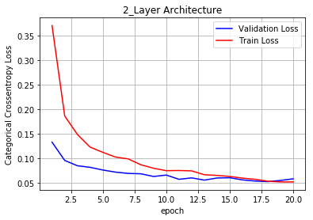

```python
score_1 = model_relu.evaluate(X_test, Y_test, verbose=0)
print('Test score:', score_1[0])
print('Test accuracy:', score_1[1])

fig,ax = plt.subplots(1,1)
ax.set_xlabel('epoch')
ax.set_ylabel('Categorical Crossentropy Loss')

# list of epoch numbers
x = list(range(1,nb_epoch+1))

vy = history.history['val_loss']
ty = history.history['loss']
plt_dynamic(x, vy, ty, ax)
plt.title('2_Layer Architecture')
plt.show()
```

### if we observe that above plot after 20 epochs our test loss may grater than our train loss

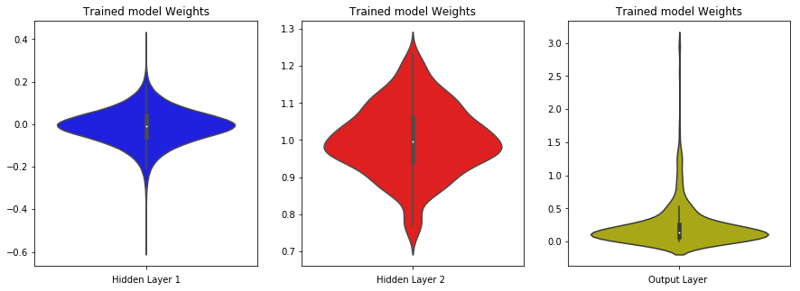

```python
w_after = model_relu.get_weights()

h1_w = w_after[0].flatten().reshape(-1,1)
h2_w = w_after[2].flatten().reshape(-1,1)
out_w = w_after[4].flatten().reshape(-1,1)


fig = plt.figure(figsize=(15,5))
plt.title("Weight matrices after model trained")
plt.subplot(1, 3, 1)
plt.title("Trained model Weights")
ax = sns.violinplot(y=h1_w,color='b')
plt.xlabel('Hidden Layer 1')

plt.subplot(1, 3, 2)
plt.title("Trained model Weights")
ax = sns.violinplot(y=h2_w, color='r')
plt.xlabel('Hidden Layer 2 ')

plt.subplot(1, 3, 3)
plt.title("Trained model Weights")
ax = sns.violinplot(y=out_w,color='y')
plt.xlabel('Output Layer ')
plt.show()
```

## 2 Layer architecture With-out Batch Normalization and Dropout

```python
model_relu = Sequential()
#layer-1
model_relu.add(Dense(500, activation='relu', input_shape=(input_dim,), kernel_initializer=RandomNormal(mean=0.0, stddev=0.039, seed=None)))
#adding batch normalization
#model_relu.add(BatchNormalization())
#addding dropout rate
#model_relu.add(Dropout(0.5))
#layer-2
model_relu.add(Dense(200, activation='relu', kernel_initializer=RandomNormal(mean=0.0, stddev=0.039, seed=None)))
#adding batch noramalization
#model_relu.add(BatchNormalization())
#adding drop out rate
#model_relu.add(Dropout(0.5))

model_relu.add(Dense(output_dim, activation='softmax'))


#print(model_relu.summary())
#using optimizer adam
model_relu.compile(optimizer='adam', loss='categorical_crossentropy', metrics=['accuracy'])

history = model_relu.fit(X_train, Y_train, batch_size=batch_size, epochs=nb_epoch, verbose=1, validation_data=(X_test, Y_test))

#------------------------------------------------------------------------------------------------------------------------------------

#-------------------------------------------------------------------------------------------------------------------------------------
```

```
Train on 60000 samples, validate on 10000 samples
```

```
Test score: 0.10529097638992689
Test accuracy: 0.9792
```

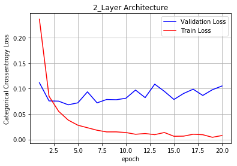

```python
score_1 = model_relu.evaluate(X_test, Y_test, verbose=0)
print('Test score:', score_1[0])
print('Test accuracy:', score_1[1])

fig,ax = plt.subplots(1,1)
ax.set_xlabel('epoch')
ax.set_ylabel('Categorical Crossentropy Loss')

# list of epoch numbers
x = list(range(1,nb_epoch+1))

vy = history.history['val_loss']
ty = history.history['loss']
plt_dynamic(x, vy, ty, ax)
plt.title('2_Layer Architecture')
plt.show()
```

### Here we see that in above plot with out apply of batch-normalization and drop out we got test loss > train loss

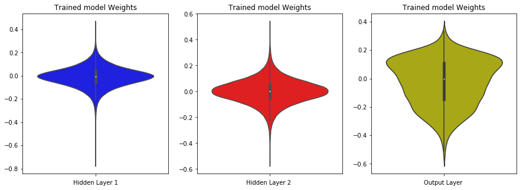

```python
w_after = model_relu.get_weights()

h1_w = w_after[0].flatten().reshape(-1,1)
h2_w = w_after[2].flatten().reshape(-1,1)
out_w = w_after[4].flatten().reshape(-1,1)


fig = plt.figure(figsize=(15,5))
plt.title("Weight matrices after model trained")
plt.subplot(1, 3, 1)
plt.title("Trained model Weights")
ax = sns.violinplot(y=h1_w,color='b')
plt.xlabel('Hidden Layer 1')

plt.subplot(1, 3, 2)
plt.title("Trained model Weights")
ax = sns.violinplot(y=h2_w, color='r')
plt.xlabel('Hidden Layer 2 ')

plt.subplot(1, 3, 3)
plt.title("Trained model Weights")
ax = sns.violinplot(y=out_w,color='y')
plt.xlabel('Output Layer ')
plt.show()
```

### 2 layer architecture We also experiment with Different optimizer like Adadelta with different drop-out rate 0.2

```
Train on 60000 samples, validate on 10000 samples
Test score: 0.06257566632076009
Test accuracy: 0.9858
```

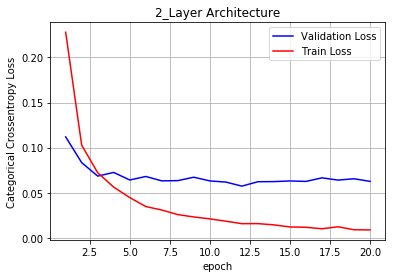

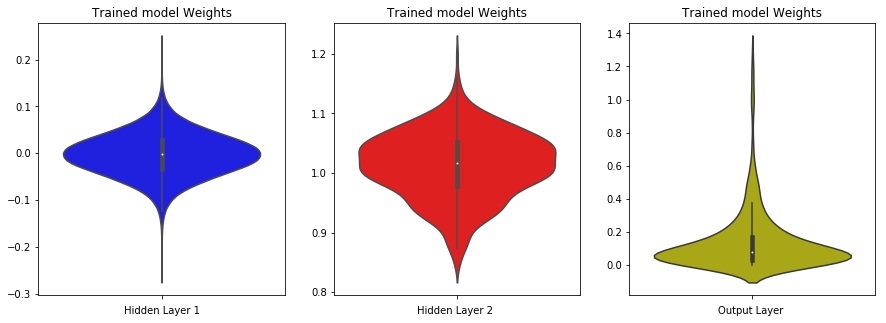

```python
model_relu = Sequential()
#layer-1
model_relu.add(Dense(500, activation='relu', input_shape=(input_dim,), kernel_initializer=RandomNormal(mean=0.0, stddev=0.039, seed=None)))
#adding batch normalization
model_relu.add(BatchNormalization())
#addding dropout rate
model_relu.add(Dropout(0.2))
#layer-2
model_relu.add(Dense(200, activation='relu', kernel_initializer=RandomNormal(mean=0.0, stddev=0.039, seed=None)))
#adding batch noramalization
model_relu.add(BatchNormalization())
#adding drop out rate
model_relu.add(Dropout(0.2))

model_relu.add(Dense(output_dim, activation='softmax'))


#print(model_relu.summary())
#using optimizer Adadelta
model_relu.compile(optimizer='Adadelta', loss='categorical_crossentropy', metrics=['accuracy'])

history = model_relu.fit(X_train, Y_train, batch_size=batch_size, epochs=nb_epoch, verbose=1, validation_data=(X_test, Y_test))

#------------------------------------------------train and test error plots ------------------------------------------------------------------------------------
score_1 = model_relu.evaluate(X_test, Y_test, verbose=0)
print('Test score:', score_1[0])
print('Test accuracy:', score_1[1])

fig,ax = plt.subplots(1,1)
ax.set_xlabel('epoch')
ax.set_ylabel('Categorical Crossentropy Loss')

# list of epoch numbers
x = list(range(1,nb_epoch+1))

vy = history.history['val_loss']
ty = history.history['loss']
plt_dynamic(x, vy, ty, ax)
plt.title('2_Layer Architecture')
plt.show()
#-------------------------------------------------------------layer wise plots ------------------------------------------------------------------------
w_after = model_relu.get_weights()

h1_w = w_after[0].flatten().reshape(-1,1)
h2_w = w_after[2].flatten().reshape(-1,1)
out_w = w_after[4].flatten().reshape(-1,1)


fig = plt.figure(figsize=(15,5))
plt.title("Weight matrices after model trained")
plt.subplot(1, 3, 1)
plt.title("Trained model Weights")
ax = sns.violinplot(y=h1_w,color='b')
plt.xlabel('Hidden Layer 1')

plt.subplot(1, 3, 2)
plt.title("Trained model Weights")
ax = sns.violinplot(y=h2_w, color='r')
plt.xlabel('Hidden Layer 2 ')

plt.subplot(1, 3, 3)
plt.title("Trained model Weights")
ax = sns.violinplot(y=out_w,color='y')
plt.xlabel('Output Layer ')
plt.show()
```

### Above We got our test-loss > train-loss which is not a good performance

### 2 layer architecture We also experiment with by Adding only one batch normalization and one drop-out after first layer with adam with drop 5.0

```
Train on 60000 samples, validate on 10000 samples
Test score: 0.054469384077978064
Test accuracy: 0.9852
```

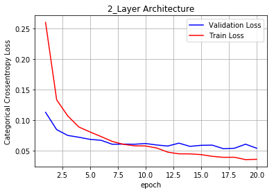

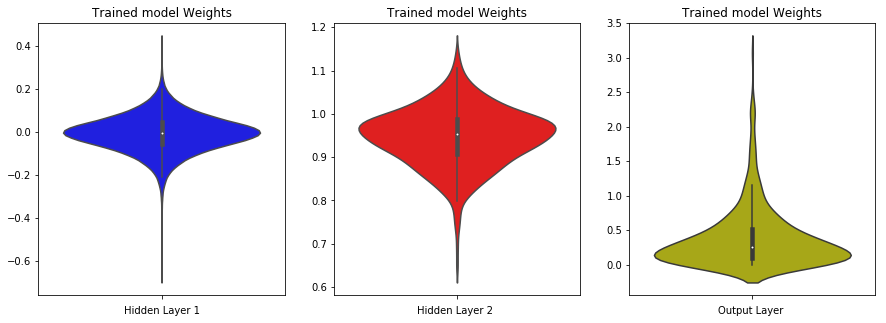

```python
model_relu = Sequential()
#layer-1
model_relu.add(Dense(500, activation='relu', input_shape=(input_dim,), kernel_initializer=RandomNormal(mean=0.0, stddev=0.039, seed=None)))
#adding batch normalization
model_relu.add(BatchNormalization())
#addding dropout rate
model_relu.add(Dropout(0.5))
#layer-2
model_relu.add(Dense(200, activation='relu', kernel_initializer=RandomNormal(mean=0.0, stddev=0.039, seed=None)))
#adding batch noramalization
#model_relu.add(BatchNormalization())
#adding drop out rate
#model_relu.add(Dropout(0.2))

model_relu.add(Dense(output_dim, activation='softmax'))


#print(model_relu.summary())
#using optimizer Adadelta
model_relu.compile(optimizer='Adam', loss='categorical_crossentropy', metrics=['accuracy'])

history = model_relu.fit(X_train, Y_train, batch_size=batch_size, epochs=nb_epoch, verbose=1, validation_data=(X_test, Y_test))

#------------------------------------------------train and test error plots ------------------------------------------------------------------------------------
score_1 = model_relu.evaluate(X_test, Y_test, verbose=0)
print('Test score:', score_1[0])
print('Test accuracy:', score_1[1])

fig,ax = plt.subplots(1,1)
ax.set_xlabel('epoch')
ax.set_ylabel('Categorical Crossentropy Loss')

# list of epoch numbers
x = list(range(1,nb_epoch+1))

vy = history.history['val_loss']
ty = history.history['loss']
plt_dynamic(x, vy, ty, ax)
plt.title('2_Layer Architecture')
plt.show()
#-------------------------------------------------------------layer wise plots ------------------------------------------------------------------------
w_after = model_relu.get_weights()

h1_w = w_after[0].flatten().reshape(-1,1)
h2_w = w_after[2].flatten().reshape(-1,1)
out_w = w_after[4].flatten().reshape(-1,1)


fig = plt.figure(figsize=(15,5))
plt.title("Weight matrices after model trained")
plt.subplot(1, 3, 1)
plt.title("Trained model Weights")
ax = sns.violinplot(y=h1_w,color='b')
plt.xlabel('Hidden Layer 1')

plt.subplot(1, 3, 2)
plt.title("Trained model Weights")
ax = sns.violinplot(y=h2_w, color='r')
plt.xlabel('Hidden Layer 2 ')

plt.subplot(1, 3, 3)
plt.title("Trained model Weights")
ax = sns.violinplot(y=out_w,color='y')
plt.xlabel('Output Layer ')
plt.show()
```

### Above We got our test-loss > train-loss which is not a good performance

### 2 layer architecture We also experiment with by Adding only one batch normalization and one-drop-out before last layer with Adam with drop 0.5

```
Train on 60000 samples, validate on 10000 samples
Test score: 0.09304900475722334
Test accuracy: 0.98
```

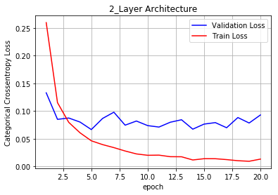

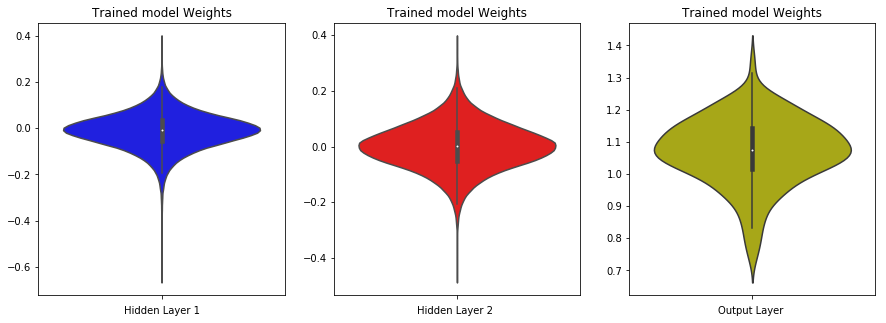

```python
model_relu = Sequential()
#layer-1
model_relu.add(Dense(500, activation='relu', input_shape=(input_dim,), kernel_initializer=RandomNormal(mean=0.0, stddev=0.039, seed=None)))
#adding batch normalization
#model_relu.add(BatchNormalization())
#addding dropout rate
#model_relu.add(Dropout(0.2))
#layer-2
model_relu.add(Dense(200, activation='relu', kernel_initializer=RandomNormal(mean=0.0, stddev=0.039, seed=None)))
#adding batch noramalization
model_relu.add(BatchNormalization())
#adding drop out rate
model_relu.add(Dropout(0.5))

model_relu.add(Dense(output_dim, activation='softmax'))


#print(model_relu.summary())
#using optimizer Adadelta
model_relu.compile(optimizer='Adam', loss='categorical_crossentropy', metrics=['accuracy'])

history = model_relu.fit(X_train, Y_train, batch_size=batch_size, epochs=nb_epoch, verbose=1, validation_data=(X_test, Y_test))

#------------------------------------------------train and test error plots ------------------------------------------------------------------------------------
score_1 = model_relu.evaluate(X_test, Y_test, verbose=0)
print('Test score:', score_1[0])
print('Test accuracy:', score_1[1])

fig,ax = plt.subplots(1,1)
ax.set_xlabel('epoch')
ax.set_ylabel('Categorical Crossentropy Loss')

# list of epoch numbers
x = list(range(1,nb_epoch+1))

vy = history.history['val_loss']
ty = history.history['loss']
plt_dynamic(x, vy, ty, ax)
plt.title('2_Layer Architecture')
plt.show()
#-------------------------------------------------------------layer wise plots ------------------------------------------------------------------------
w_after = model_relu.get_weights()

h1_w = w_after[0].flatten().reshape(-1,1)
h2_w = w_after[2].flatten().reshape(-1,1)
out_w = w_after[4].flatten().reshape(-1,1)


fig = plt.figure(figsize=(15,5))
plt.title("Weight matrices after model trained")
plt.subplot(1, 3, 1)
plt.title("Trained model Weights")
ax = sns.violinplot(y=h1_w,color='b')
plt.xlabel('Hidden Layer 1')

plt.subplot(1, 3, 2)
plt.title("Trained model Weights")
ax = sns.violinplot(y=h2_w, color='r')
plt.xlabel('Hidden Layer 2 ')

plt.subplot(1, 3, 3)
plt.title("Trained model Weights")
ax = sns.violinplot(y=out_w,color='y')
plt.xlabel('Output Layer ')
plt.show()
```

### Above We got our test-loss > train-loss which is not a good performance

## 3-layer Architecture with Batch-Normalization and Dropout

```python
model_relu2 = Sequential()
#layer-1
model_relu2.add(Dense(500, activation='relu', input_shape=(input_dim,), kernel_initializer=RandomNormal(mean=0.0, stddev=0.039, seed=None)))
#adding batch normalization
model_relu2.add(BatchNormalization())
#addding dropout rate
model_relu2.add(Dropout(0.5))
#layer-2
model_relu2.add(Dense(300, activation='relu', kernel_initializer=RandomNormal(mean=0.0, stddev=0.039, seed=None)))
#adding batch noramalization
model_relu2.add(BatchNormalization())
#adding drop out rate
model_relu2.add(Dropout(0.5))
#layer-3
model_relu2.add(Dense(200, activation='relu', kernel_initializer=RandomNormal(mean=0.0, stddev=0.039, seed=None)))
#adding batch noramalization
model_relu2.add(BatchNormalization())
#adding drop out rate
model_relu2.add(Dropout(0.5))

model_relu2.add(Dense(output_dim, activation='softmax'))


#print(model_relu2.summary())
#using optimizer adam
model_relu2.compile(optimizer='adam', loss='categorical_crossentropy', metrics=['accuracy'])

history = model_relu2.fit(X_train, Y_train, batch_size=batch_size, epochs=nb_epoch, verbose=1, validation_data=(X_test, Y_test))
```

```
Train on 60000 samples, validate on 10000 samples
```

```
Test score: 0.0504366103822249
Test accuracy: 0.9849
```

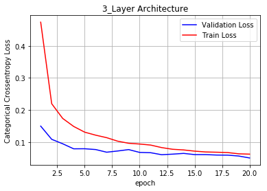

```python
score_4 = model_relu2.evaluate(X_test, Y_test, verbose=0)
print('Test score:', score_4[0])
print('Test accuracy:', score_4[1])

fig,ax = plt.subplots(1,1)
ax.set_xlabel('epoch')
ax.set_ylabel('Categorical Crossentropy Loss')

# list of epoch numbers
x = list(range(1,nb_epoch+1))

vy = history.history['val_loss']
ty = history.history['loss']
plt_dynamic(x, vy, ty, ax)
plt.title('3_Layer Architecture')
plt.show()
```

### In above plot at epoch 20 our train and test loss becomes same

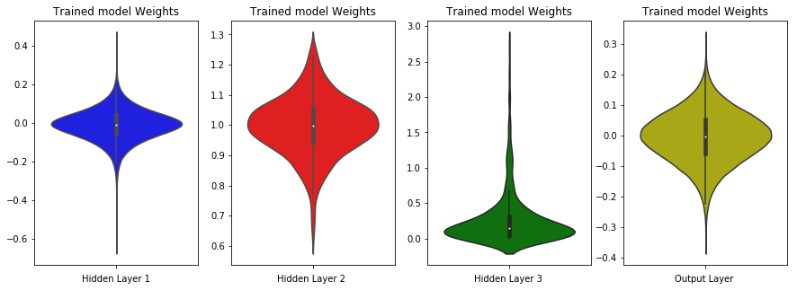

```python
w_after = model_relu2.get_weights()

h1_w = w_after[0].flatten().reshape(-1,1)
h2_w = w_after[2].flatten().reshape(-1,1)
h3_w = w_after[4].flatten().reshape(-1,1)

out_w = w_after[6].flatten().reshape(-1,1)


fig = plt.figure(figsize=(15,5))
plt.title("Weight matrices after model trained")
plt.subplot(1, 4, 1)
plt.title("Trained model Weights")
ax = sns.violinplot(y=h1_w,color='b')
plt.xlabel('Hidden Layer 1')

plt.subplot(1, 4, 2)
plt.title("Trained model Weights")
ax = sns.violinplot(y=h2_w, color='r')
plt.xlabel('Hidden Layer 2 ')

plt.subplot(1, 4, 3)
plt.title("Trained model Weights")
ax = sns.violinplot(y=h3_w, color='g')
plt.xlabel('Hidden Layer 3 ')


plt.subplot(1, 4, 4)
plt.title("Trained model Weights")
ax = sns.violinplot(y=out_w,color='y')
plt.xlabel('Output Layer ')
plt.show()
```

## 3-layer Architecture with-out Batch-Normalization and Dropout

```python
model_relu2 = Sequential()
#layer-1
model_relu2.add(Dense(500, activation='relu', input_shape=(input_dim,), kernel_initializer=RandomNormal(mean=0.0, stddev=0.039, seed=None)))
#adding batch normalization
#model_relu2.add(BatchNormalization())
#addding dropout rate
#model_relu2.add(Dropout(0.5))
#layer-2
model_relu2.add(Dense(300, activation='relu', kernel_initializer=RandomNormal(mean=0.0, stddev=0.039, seed=None)))
#adding batch noramalization
#model_relu2.add(BatchNormalization())
#adding drop out rate
#model_relu2.add(Dropout(0.5))
#layer-3
model_relu2.add(Dense(200, activation='relu', kernel_initializer=RandomNormal(mean=0.0, stddev=0.039, seed=None)))
#adding batch noramalization
#model_relu2.add(BatchNormalization())
#adding drop out rate
#model_relu2.add(Dropout(0.5))

model_relu2.add(Dense(output_dim, activation='softmax'))


#print(model_relu2.summary())
#using optimizer adam
model_relu2.compile(optimizer='adam', loss='categorical_crossentropy', metrics=['accuracy'])

history = model_relu2.fit(X_train, Y_train, batch_size=batch_size, epochs=nb_epoch, verbose=1, validation_data=(X_test, Y_test))

#---------------------------------------------------------------------------------------------------------------------------------------------
```

```
Train on 60000 samples, validate on 10000 samples
```

```
Test score: 0.09140819830668388
Test accuracy: 0.9813
```

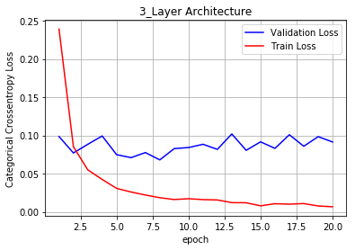

```python
score_4 = model_relu2.evaluate(X_test, Y_test, verbose=0)
print('Test score:', score_4[0])
print('Test accuracy:', score_4[1])

fig,ax = plt.subplots(1,1)
ax.set_xlabel('epoch')
ax.set_ylabel('Categorical Crossentropy Loss')

# list of epoch numbers
x = list(range(1,nb_epoch+1))

vy = history.history['val_loss']
ty = history.history['loss']
plt_dynamic(x, vy, ty, ax)
plt.title('3_Layer Architecture')
plt.show()
```

### Here we see that in above plot with out apply of batch-normalization and drop out we got test loss > train loss

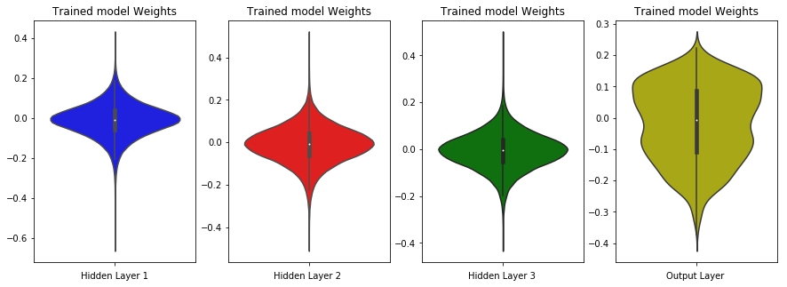

```python
w_after = model_relu2.get_weights()

h1_w = w_after[0].flatten().reshape(-1,1)
h2_w = w_after[2].flatten().reshape(-1,1)
h3_w = w_after[4].flatten().reshape(-1,1)

out_w = w_after[6].flatten().reshape(-1,1)

fig = plt.figure(figsize=(15,5))
plt.title("Weight matrices after model trained")

plt.subplot(1, 4, 1)

plt.title("Trained model Weights")
ax = sns.violinplot(y=h1_w,color='b')
plt.xlabel('Hidden Layer 1')

plt.subplot(1, 4, 2)
plt.title("Trained model Weights")
ax = sns.violinplot(y=h2_w, color='r')
plt.xlabel('Hidden Layer 2 ')

plt.subplot(1, 4, 3)
plt.title("Trained model Weights")
ax = sns.violinplot(y=h3_w, color='g')
plt.xlabel('Hidden Layer 3 ')


plt.subplot(1, 4, 4)
plt.title("Trained model Weights")
ax = sns.violinplot(y=out_w,color='y')
plt.xlabel('Output Layer ')
plt.show()
```

### 3 layer architecture We also experiment with Different optimizer like Adadelta with different drop-out rate 0.2

```
Train on 60000 samples, validate on 10000 samples
Test score: 0.05980458545034853
Test accuracy: 0.9845
```

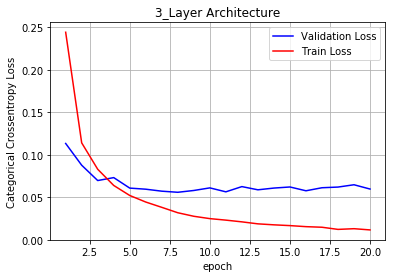

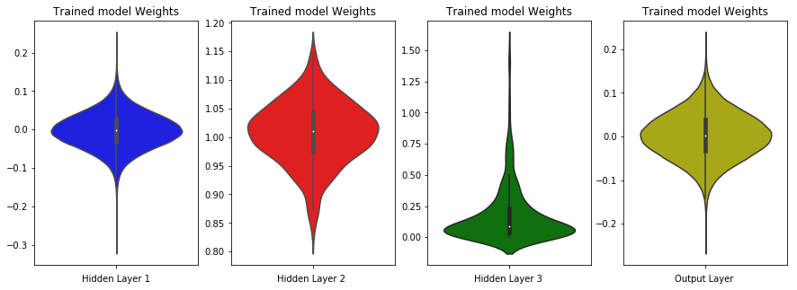

```python
model_relu2 = Sequential()
#layer-1
model_relu2.add(Dense(500, activation='relu', input_shape=(input_dim,), kernel_initializer=RandomNormal(mean=0.0, stddev=0.039, seed=None)))
#adding batch normalization
model_relu2.add(BatchNormalization())
#addding dropout rate
model_relu2.add(Dropout(0.2))
#layer-2
model_relu2.add(Dense(300, activation='relu', kernel_initializer=RandomNormal(mean=0.0, stddev=0.039, seed=None)))
#adding batch noramalization
model_relu2.add(BatchNormalization())
#adding drop out rate
model_relu2.add(Dropout(0.2))
#layer-3
model_relu2.add(Dense(200, activation='relu', kernel_initializer=RandomNormal(mean=0.0, stddev=0.039, seed=None)))
#adding batch noramalization
model_relu2.add(BatchNormalization())
#adding drop out rate
model_relu2.add(Dropout(0.2))

model_relu2.add(Dense(output_dim, activation='softmax'))


#print(model_relu2.summary())
#using optimizer adam
model_relu2.compile(optimizer='Adadelta', loss='categorical_crossentropy', metrics=['accuracy'])

history = model_relu2.fit(X_train, Y_train, batch_size=batch_size, epochs=nb_epoch, verbose=1, validation_data=(X_test, Y_test))

#-------------------------------------------------------------train and test error --------------------------------------------------------------------------------

score_4 = model_relu2.evaluate(X_test, Y_test, verbose=0)
print('Test score:', score_4[0])
print('Test accuracy:', score_4[1])

fig,ax = plt.subplots(1,1)
ax.set_xlabel('epoch')
ax.set_ylabel('Categorical Crossentropy Loss')

# list of epoch numbers
x = list(range(1,nb_epoch+1))

vy = history.history['val_loss']
ty = history.history['loss']
plt_dynamic(x, vy, ty, ax)
plt.title('3_Layer Architecture')
plt.show()

#-------------------------------------------------------------------layers performance ------------------------------------------------------------------
w_after = model_relu2.get_weights()

h1_w = w_after[0].flatten().reshape(-1,1)
h2_w = w_after[2].flatten().reshape(-1,1)
h3_w = w_after[4].flatten().reshape(-1,1)

out_w = w_after[6].flatten().reshape(-1,1)

fig = plt.figure(figsize=(15,5))
plt.title("Weight matrices after model trained")

plt.subplot(1, 4, 1)

plt.title("Trained model Weights")
ax = sns.violinplot(y=h1_w,color='b')
plt.xlabel('Hidden Layer 1')

plt.subplot(1, 4, 2)
plt.title("Trained model Weights")
ax = sns.violinplot(y=h2_w, color='r')
plt.xlabel('Hidden Layer 2 ')

plt.subplot(1, 4, 3)
plt.title("Trained model Weights")
ax = sns.violinplot(y=h3_w, color='g')
plt.xlabel('Hidden Layer 3 ')


plt.subplot(1, 4, 4)
plt.title("Trained model Weights")
ax = sns.violinplot(y=out_w,color='y')
plt.xlabel('Output Layer ')
plt.show()
```

### Above We got our test-loss > train-loss which is not a good performance

### 3 layer architecture Here below we experiment with one batch-normalization and 1 drop out layer at begining of the architecture with Adam optimizer and drop 0.5

```
Train on 60000 samples, validate on 10000 samples
Test score: 0.058732410513349896
Test accuracy: 0.9839
```

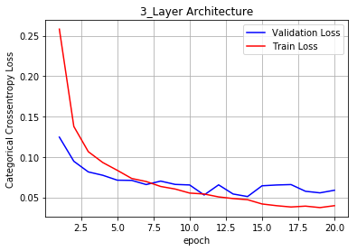

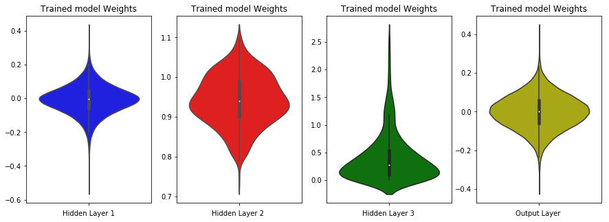

```python
model_relu2 = Sequential()
#layer-1
model_relu2.add(Dense(500, activation='relu', input_shape=(input_dim,), kernel_initializer=RandomNormal(mean=0.0, stddev=0.039, seed=None)))
#adding batch normalization
model_relu2.add(BatchNormalization())
#addding dropout rate
model_relu2.add(Dropout(0.5))
#layer-2
model_relu2.add(Dense(300, activation='relu', kernel_initializer=RandomNormal(mean=0.0, stddev=0.039, seed=None)))
#adding batch noramalization
#model_relu2.add(BatchNormalization())
#adding drop out rate
#model_relu2.add(Dropout(0.2))
#layer-3
model_relu2.add(Dense(200, activation='relu', kernel_initializer=RandomNormal(mean=0.0, stddev=0.039, seed=None)))
#adding batch noramalization
#model_relu2.add(BatchNormalization())
#adding drop out rate
#model_relu2.add(Dropout(0.2))

model_relu2.add(Dense(output_dim, activation='softmax'))


#print(model_relu2.summary())
#using optimizer adam
model_relu2.compile(optimizer='Adam', loss='categorical_crossentropy', metrics=['accuracy'])

history = model_relu2.fit(X_train, Y_train, batch_size=batch_size, epochs=nb_epoch, verbose=1, validation_data=(X_test, Y_test))

#-------------------------------------------------------------train and test error --------------------------------------------------------------------------------

score_4 = model_relu2.evaluate(X_test, Y_test, verbose=0)
print('Test score:', score_4[0])
print('Test accuracy:', score_4[1])

fig,ax = plt.subplots(1,1)
ax.set_xlabel('epoch')
ax.set_ylabel('Categorical Crossentropy Loss')

# list of epoch numbers
x = list(range(1,nb_epoch+1))

vy = history.history['val_loss']
ty = history.history['loss']
plt_dynamic(x, vy, ty, ax)
plt.title('3_Layer Architecture')
plt.show()

#-------------------------------------------------------------------layers performance ------------------------------------------------------------------
w_after = model_relu2.get_weights()

h1_w = w_after[0].flatten().reshape(-1,1)
h2_w = w_after[2].flatten().reshape(-1,1)
h3_w = w_after[4].flatten().reshape(-1,1)

out_w = w_after[6].flatten().reshape(-1,1)

fig = plt.figure(figsize=(15,5))
plt.title("Weight matrices after model trained")

plt.subplot(1, 4, 1)

plt.title("Trained model Weights")
ax = sns.violinplot(y=h1_w,color='b')
plt.xlabel('Hidden Layer 1')

plt.subplot(1, 4, 2)
plt.title("Trained model Weights")
ax = sns.violinplot(y=h2_w, color='r')
plt.xlabel('Hidden Layer 2 ')

plt.subplot(1, 4, 3)
plt.title("Trained model Weights")
ax = sns.violinplot(y=h3_w, color='g')
plt.xlabel('Hidden Layer 3 ')


plt.subplot(1, 4, 4)
plt.title("Trained model Weights")
ax = sns.violinplot(y=out_w,color='y')
plt.xlabel('Output Layer ')
plt.show()
```

### Above We got our test-loss > train-loss which is not a good performance

```
Train on 60000 samples, validate on 10000 samples
Test score: 0.06620450230908602
Test accuracy: 0.9866
```

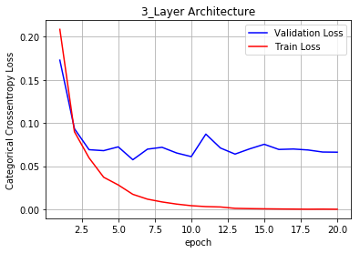

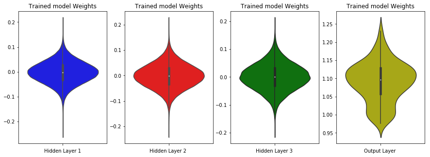

```python
model_relu2 = Sequential()
#layer-1
model_relu2.add(Dense(500, activation='relu', input_shape=(input_dim,), kernel_initializer=RandomNormal(mean=0.0, stddev=0.039, seed=None)))
#adding batch normalization
#model_relu2.add(BatchNormalization())
#addding dropout rate
#model_relu2.add(Dropout(0.2))
#layer-2
model_relu2.add(Dense(300, activation='relu', kernel_initializer=RandomNormal(mean=0.0, stddev=0.039, seed=None)))
#adding batch noramalization
#model_relu2.add(BatchNormalization())
#adding drop out rate
#model_relu2.add(Dropout(0.2))
#layer-3
model_relu2.add(Dense(200, activation='relu', kernel_initializer=RandomNormal(mean=0.0, stddev=0.039, seed=None)))
#adding batch noramalization
model_relu2.add(BatchNormalization())
#adding drop out rate
model_relu2.add(Dropout(0.2))

model_relu2.add(Dense(output_dim, activation='softmax'))


#print(model_relu2.summary())
#using optimizer adam
model_relu2.compile(optimizer='Adadelta', loss='categorical_crossentropy', metrics=['accuracy'])

history = model_relu2.fit(X_train, Y_train, batch_size=batch_size, epochs=nb_epoch, verbose=1, validation_data=(X_test, Y_test))

#-------------------------------------------------------------train and test error --------------------------------------------------------------------------------

score_4 = model_relu2.evaluate(X_test, Y_test, verbose=0)
print('Test score:', score_4[0])
print('Test accuracy:', score_4[1])

fig,ax = plt.subplots(1,1)
ax.set_xlabel('epoch')
ax.set_ylabel('Categorical Crossentropy Loss')

# list of epoch numbers
x = list(range(1,nb_epoch+1))

vy = history.history['val_loss']
ty = history.history['loss']
plt_dynamic(x, vy, ty, ax)
plt.title('3_Layer Architecture')
plt.show()

#-------------------------------------------------------------------layers performance ------------------------------------------------------------------
w_after = model_relu2.get_weights()

h1_w = w_after[0].flatten().reshape(-1,1)
h2_w = w_after[2].flatten().reshape(-1,1)
h3_w = w_after[4].flatten().reshape(-1,1)

out_w = w_after[6].flatten().reshape(-1,1)

fig = plt.figure(figsize=(15,5))
plt.title("Weight matrices after model trained")

plt.subplot(1, 4, 1)

plt.title("Trained model Weights")
ax = sns.violinplot(y=h1_w,color='b')
plt.xlabel('Hidden Layer 1')

plt.subplot(1, 4, 2)
plt.title("Trained model Weights")
ax = sns.violinplot(y=h2_w, color='r')
plt.xlabel('Hidden Layer 2 ')

plt.subplot(1, 4, 3)
plt.title("Trained model Weights")
ax = sns.violinplot(y=h3_w, color='g')
plt.xlabel('Hidden Layer 3 ')


plt.subplot(1, 4, 4)
plt.title("Trained model Weights")
ax = sns.violinplot(y=out_w,color='y')
plt.xlabel('Output Layer ')
plt.show()
```

### Above We got our test-loss > train-loss which is not a good performance

## 5-layer Architecture with Batch-Normalization and Dropout

```python
model_relu3 = Sequential()
#layer-1
model_relu3.add(Dense(500, activation='relu', input_shape=(input_dim,), kernel_initializer=RandomNormal(mean=0.0, stddev=0.039, seed=None)))
#adding batch normalization
model_relu3.add(BatchNormalization())
#addding dropout rate
model_relu3.add(Dropout(0.5))
#layer-2
model_relu3.add(Dense(400, activation='relu', kernel_initializer=RandomNormal(mean=0.0, stddev=0.039, seed=None)))
#adding batch noramalization
model_relu3.add(BatchNormalization())
#adding drop out rate
model_relu3.add(Dropout(0.5))
#layer-3
model_relu3.add(Dense(300, activation='relu', kernel_initializer=RandomNormal(mean=0.0, stddev=0.039, seed=None)))
#adding batch noramalization
model_relu3.add(BatchNormalization())
#adding drop out rate
model_relu3.add(Dropout(0.5))
#layer-4
model_relu3.add(Dense(200, activation='relu', kernel_initializer=RandomNormal(mean=0.0, stddev=0.039, seed=None)))
#adding batch noramalization
model_relu3.add(BatchNormalization())
#adding drop out rate
model_relu3.add(Dropout(0.5))
#layer-5
model_relu3.add(Dense(100, activation='relu', kernel_initializer=RandomNormal(mean=0.0, stddev=0.039, seed=None)))
#adding batch noramalization
model_relu3.add(BatchNormalization())
#adding drop out rate
model_relu3.add(Dropout(0.5))

model_relu3.add(Dense(output_dim, activation='softmax'))


#print(model_relu3.summary())
#using optimizer adam
model_relu3.compile(optimizer='adam', loss='categorical_crossentropy', metrics=['accuracy'])

history = model_relu3.fit(X_train, Y_train, batch_size=batch_size, epochs=nb_epoch, verbose=1, validation_data=(X_test, Y_test))
```

```
Train on 60000 samples, validate on 10000 samples
```

```
Test score: 0.066039138047304
Test accuracy: 0.9824
```

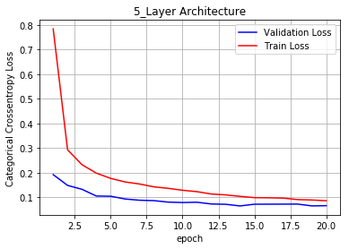

```python
score_6 = model_relu3.evaluate(X_test, Y_test, verbose=0)
print('Test score:', score_6[0])
print('Test accuracy:', score_6[1])

fig,ax = plt.subplots(1,1)
ax.set_xlabel('epoch')
ax.set_ylabel('Categorical Crossentropy Loss')

# list of epoch numbers
x = list(range(1,nb_epoch+1))

vy = history.history['val_loss']
ty = history.history['loss']
plt_dynamic(x, vy, ty, ax)
plt.title('5_Layer Architecture')
plt.show()
```

### In above plot it maintains smaller error distance from train to test

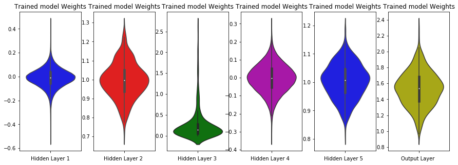

```python
w_after = model_relu3.get_weights()

h1_w = w_after[0].flatten().reshape(-1,1)
h2_w = w_after[2].flatten().reshape(-1,1)
h3_w = w_after[4].flatten().reshape(-1,1)
h4_w = w_after[6].flatten().reshape(-1,1)
h5_w = w_after[8].flatten().reshape(-1,1)

out_w = w_after[10].flatten().reshape(-1,1)

fig = plt.figure(figsize=(15,5))
plt.title("Weight matrices after model trained")

plt.subplot(1, 6, 1,)

plt.title("Trained model Weights")
ax = sns.violinplot(y=h1_w,color='b')
plt.xlabel('Hidden Layer 1')

plt.subplot(1, 6, 2)
plt.title("Trained model Weights")
ax = sns.violinplot(y=h2_w, color='r')
plt.xlabel('Hidden Layer 2 ')

plt.subplot(1, 6, 3)
plt.title("Trained model Weights")
ax = sns.violinplot(y=h3_w, color='g')
plt.xlabel('Hidden Layer 3 ')


plt.subplot(1, 6, 4)
plt.title("Trained model Weights")
ax = sns.violinplot(y=h4_w,color='m')
plt.xlabel('Hidden Layer 4  ')

plt.subplot(1, 6, 5)
plt.title("Trained model Weights")
ax = sns.violinplot(y=h5_w,color='b')
plt.xlabel('Hidden Layer 5  ')

plt.subplot(1, 6, 6)
plt.title("Trained model Weights")
ax = sns.violinplot(y=out_w,color='y')
plt.xlabel('Output Layer ')
plt.show()
```

## 5-layer Architecture with-out Batch-Normalization and Dropout

```python
model_relu3 = Sequential()
#layer-1
model_relu3.add(Dense(500, activation='relu', input_shape=(input_dim,), kernel_initializer=RandomNormal(mean=0.0, stddev=0.039, seed=None)))
#adding batch normalization
#model_relu3.add(BatchNormalization())
#addding dropout rate
#model_relu3.add(Dropout(0.5))
#layer-2
model_relu3.add(Dense(400, activation='relu', kernel_initializer=RandomNormal(mean=0.0, stddev=0.039, seed=None)))
#adding batch noramalization
#model_relu3.add(BatchNormalization())
#adding drop out rate
#model_relu3.add(Dropout(0.5))
#layer-3
model_relu3.add(Dense(300, activation='relu', kernel_initializer=RandomNormal(mean=0.0, stddev=0.039, seed=None)))
#adding batch noramalization
#model_relu3.add(BatchNormalization())
#adding drop out rate
#model_relu3.add(Dropout(0.5))
#layer-4
model_relu3.add(Dense(200, activation='relu', kernel_initializer=RandomNormal(mean=0.0, stddev=0.039, seed=None)))
#adding batch noramalization
#model_relu3.add(BatchNormalization())
#adding drop out rate
#model_relu3.add(Dropout(0.5))
#layer-5
model_relu3.add(Dense(100, activation='relu', kernel_initializer=RandomNormal(mean=0.0, stddev=0.039, seed=None)))
#adding batch noramalization
#model_relu3.add(BatchNormalization())
#adding drop out rate
#model_relu3.add(Dropout(0.5))

model_relu3.add(Dense(output_dim, activation='softmax'))


#print(model_relu3.summary())
#using optimizer adam
model_relu3.compile(optimizer='adam', loss='categorical_crossentropy', metrics=['accuracy'])

history = model_relu3.fit(X_train, Y_train, batch_size=batch_size, epochs=nb_epoch, verbose=1, validation_data=(X_test, Y_test))
```

```
Train on 60000 samples, validate on 10000 samples
```

```
Test score: 0.08883313840526234
Test accuracy: 0.983
```

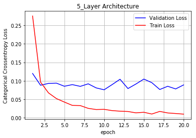

```python
score_6 = model_relu3.evaluate(X_test, Y_test, verbose=0)
print('Test score:', score_6[0])
print('Test accuracy:', score_6[1])

fig,ax = plt.subplots(1,1)
ax.set_xlabel('epoch')
ax.set_ylabel('Categorical Crossentropy Loss')

# list of epoch numbers
x = list(range(1,nb_epoch+1))

vy = history.history['val_loss']
ty = history.history['loss']
plt_dynamic(x, vy, ty, ax)
plt.title('5_Layer Architecture')
plt.show()
```

### Here we see that in above plot with out apply of batch-normalization and drop out we got test loss > train loss

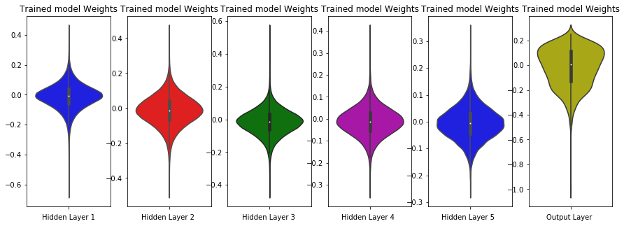

```python
w_after = model_relu3.get_weights()

h1_w = w_after[0].flatten().reshape(-1,1)
h2_w = w_after[2].flatten().reshape(-1,1)
h3_w = w_after[4].flatten().reshape(-1,1)
h4_w = w_after[6].flatten().reshape(-1,1)
h5_w = w_after[8].flatten().reshape(-1,1)

out_w = w_after[10].flatten().reshape(-1,1)

fig = plt.figure(figsize=(15,5))
plt.title("Weight matrices after model trained")

plt.subplot(1, 6, 1,)

plt.title("Trained model Weights")
ax = sns.violinplot(y=h1_w,color='b')
plt.xlabel('Hidden Layer 1')

plt.subplot(1, 6, 2)
plt.title("Trained model Weights")
ax = sns.violinplot(y=h2_w, color='r')
plt.xlabel('Hidden Layer 2 ')

plt.subplot(1, 6, 3)
plt.title("Trained model Weights")
ax = sns.violinplot(y=h3_w, color='g')
plt.xlabel('Hidden Layer 3 ')


plt.subplot(1, 6, 4)
plt.title("Trained model Weights")
ax = sns.violinplot(y=h4_w,color='m')
plt.xlabel('Hidden Layer 4  ')

plt.subplot(1, 6, 5)
plt.title("Trained model Weights")
ax = sns.violinplot(y=h5_w,color='b')
plt.xlabel('Hidden Layer 5  ')

plt.subplot(1, 6, 6)
plt.title("Trained model Weights")
ax = sns.violinplot(y=out_w,color='y')
plt.xlabel('Output Layer ')
plt.show()
```

### 5 layer architecture We also experiment with Different optimizer like Adadelta with different drop-out rate 0.2

```
Train on 60000 samples, validate on 10000 samples
Test score: 0.06405649431259226
Test accuracy: 0.9845
```

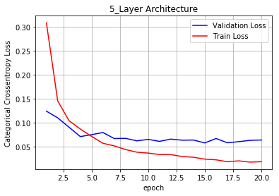

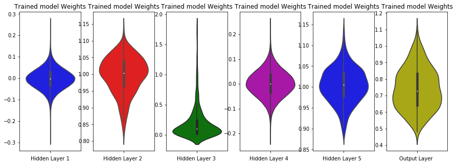

```python
model_relu3 = Sequential()
#layer-1
model_relu3.add(Dense(500, activation='relu', input_shape=(input_dim,), kernel_initializer=RandomNormal(mean=0.0, stddev=0.039, seed=None)))
#adding batch normalization
model_relu3.add(BatchNormalization())
#addding dropout rate
model_relu3.add(Dropout(0.2))
#layer-2
model_relu3.add(Dense(400, activation='relu', kernel_initializer=RandomNormal(mean=0.0, stddev=0.039, seed=None)))
#adding batch noramalization
model_relu3.add(BatchNormalization())
#adding drop out rate
model_relu3.add(Dropout(0.2))
#layer-3
model_relu3.add(Dense(300, activation='relu', kernel_initializer=RandomNormal(mean=0.0, stddev=0.039, seed=None)))
#adding batch noramalization
model_relu3.add(BatchNormalization())
#adding drop out rate
model_relu3.add(Dropout(0.2))
#layer-4
model_relu3.add(Dense(200, activation='relu', kernel_initializer=RandomNormal(mean=0.0, stddev=0.039, seed=None)))
#adding batch noramalization
model_relu3.add(BatchNormalization())
#adding drop out rate
model_relu3.add(Dropout(0.2))
#layer-5
model_relu3.add(Dense(100, activation='relu', kernel_initializer=RandomNormal(mean=0.0, stddev=0.039, seed=None)))
#adding batch noramalization
model_relu3.add(BatchNormalization())
#adding drop out rate
model_relu3.add(Dropout(0.2))

model_relu3.add(Dense(output_dim, activation='softmax'))


#print(model_relu3.summary())
#using optimizer adam
model_relu3.compile(optimizer='Adadelta', loss='categorical_crossentropy', metrics=['accuracy'])

history = model_relu3.fit(X_train, Y_train, batch_size=batch_size, epochs=nb_epoch, verbose=1, validation_data=(X_test, Y_test))
#-----------------------------------------------------------------------------------------------------------------------------------------
score_6 = model_relu3.evaluate(X_test, Y_test, verbose=0)
print('Test score:', score_6[0])
print('Test accuracy:', score_6[1])

fig,ax = plt.subplots(1,1)
ax.set_xlabel('epoch')
ax.set_ylabel('Categorical Crossentropy Loss')

# list of epoch numbers
x = list(range(1,nb_epoch+1))

vy = history.history['val_loss']
ty = history.history['loss']
plt_dynamic(x, vy, ty, ax)
plt.title('5_Layer Architecture')
plt.show()

#------------------------------------------------------------------------------------------------------------------------------------------
w_after = model_relu3.get_weights()

h1_w = w_after[0].flatten().reshape(-1,1)
h2_w = w_after[2].flatten().reshape(-1,1)
h3_w = w_after[4].flatten().reshape(-1,1)
h4_w = w_after[6].flatten().reshape(-1,1)
h5_w = w_after[8].flatten().reshape(-1,1)

out_w = w_after[10].flatten().reshape(-1,1)

fig = plt.figure(figsize=(15,5))
plt.title("Weight matrices after model trained")

plt.subplot(1, 6, 1,)

plt.title("Trained model Weights")
ax = sns.violinplot(y=h1_w,color='b')
plt.xlabel('Hidden Layer 1')

plt.subplot(1, 6, 2)
plt.title("Trained model Weights")
ax = sns.violinplot(y=h2_w, color='r')
plt.xlabel('Hidden Layer 2 ')

plt.subplot(1, 6, 3)
plt.title("Trained model Weights")
ax = sns.violinplot(y=h3_w, color='g')
plt.xlabel('Hidden Layer 3 ')


plt.subplot(1, 6, 4)
plt.title("Trained model Weights")
ax = sns.violinplot(y=h4_w,color='m')
plt.xlabel('Hidden Layer 4  ')

plt.subplot(1, 6, 5)
plt.title("Trained model Weights")
ax = sns.violinplot(y=h5_w,color='b')
plt.xlabel('Hidden Layer 5  ')

plt.subplot(1, 6, 6)
plt.title("Trained model Weights")
ax = sns.violinplot(y=out_w,color='y')
plt.xlabel('Output Layer ')
plt.show()
```

### Above We got our test-loss > train-loss which is not a good performance

### 5 layer architecture Here below we experiment with one batch-normalization and 1 drop out layer in the begining of the architecture it means after first layer with Adam optimizer

```
Train on 60000 samples, validate on 10000 samples
Test score: 0.08574480261191275
Test accuracy: 0.9807
```

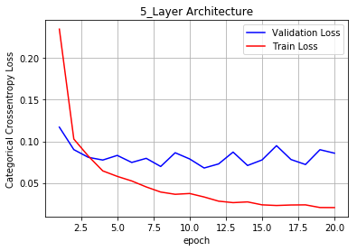

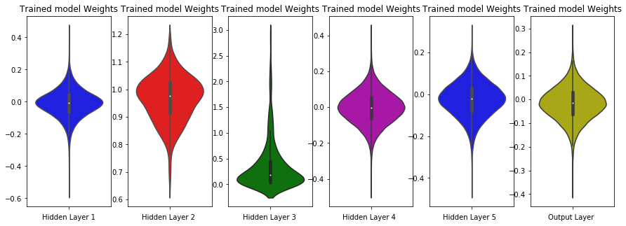

```python
model_relu3 = Sequential()
#layer-1
model_relu3.add(Dense(500, activation='relu', input_shape=(input_dim,), kernel_initializer=RandomNormal(mean=0.0, stddev=0.039, seed=None)))
#adding batch normalization
model_relu3.add(BatchNormalization())
#addding dropout rate
model_relu3.add(Dropout(0.2))
#layer-2
model_relu3.add(Dense(400, activation='relu', kernel_initializer=RandomNormal(mean=0.0, stddev=0.039, seed=None)))
#adding batch noramalization
#model_relu3.add(BatchNormalization())
#adding drop out rate
#model_relu3.add(Dropout(0.2))
#layer-3
model_relu3.add(Dense(300, activation='relu', kernel_initializer=RandomNormal(mean=0.0, stddev=0.039, seed=None)))
#adding batch noramalization
#model_relu3.add(BatchNormalization())
#adding drop out rate
#model_relu3.add(Dropout(0.2))
#layer-4
model_relu3.add(Dense(200, activation='relu', kernel_initializer=RandomNormal(mean=0.0, stddev=0.039, seed=None)))
#adding batch noramalization
#model_relu3.add(BatchNormalization())
#adding drop out rate
#model_relu3.add(Dropout(0.2))
#layer-5
model_relu3.add(Dense(100, activation='relu', kernel_initializer=RandomNormal(mean=0.0, stddev=0.039, seed=None)))
#adding batch noramalization
#model_relu3.add(BatchNormalization())
#adding drop out rate
#model_relu3.add(Dropout(0.2))

model_relu3.add(Dense(output_dim, activation='softmax'))


#print(model_relu3.summary())
#using optimizer adam
model_relu3.compile(optimizer='adam', loss='categorical_crossentropy', metrics=['accuracy'])

history = model_relu3.fit(X_train, Y_train, batch_size=batch_size, epochs=nb_epoch, verbose=1, validation_data=(X_test, Y_test))
#-----------------------------------------------------------------------------------------------------------------------------------------
score_6 = model_relu3.evaluate(X_test, Y_test, verbose=0)
print('Test score:', score_6[0])
print('Test accuracy:', score_6[1])

fig,ax = plt.subplots(1,1)
ax.set_xlabel('epoch')
ax.set_ylabel('Categorical Crossentropy Loss')

# list of epoch numbers
x = list(range(1,nb_epoch+1))

vy = history.history['val_loss']
ty = history.history['loss']
plt_dynamic(x, vy, ty, ax)
plt.title('5_Layer Architecture')
plt.show()

#------------------------------------------------------------------------------------------------------------------------------------------
w_after = model_relu3.get_weights()

h1_w = w_after[0].flatten().reshape(-1,1)
h2_w = w_after[2].flatten().reshape(-1,1)
h3_w = w_after[4].flatten().reshape(-1,1)
h4_w = w_after[6].flatten().reshape(-1,1)
h5_w = w_after[8].flatten().reshape(-1,1)

out_w = w_after[10].flatten().reshape(-1,1)

fig = plt.figure(figsize=(15,5))
plt.title("Weight matrices after model trained")

plt.subplot(1, 6, 1,)

plt.title("Trained model Weights")
ax = sns.violinplot(y=h1_w,color='b')
plt.xlabel('Hidden Layer 1')

plt.subplot(1, 6, 2)
plt.title("Trained model Weights")
ax = sns.violinplot(y=h2_w, color='r')
plt.xlabel('Hidden Layer 2 ')

plt.subplot(1, 6, 3)
plt.title("Trained model Weights")
ax = sns.violinplot(y=h3_w, color='g')
plt.xlabel('Hidden Layer 3 ')


plt.subplot(1, 6, 4)
plt.title("Trained model Weights")
ax = sns.violinplot(y=h4_w,color='m')
plt.xlabel('Hidden Layer 4  ')

plt.subplot(1, 6, 5)
plt.title("Trained model Weights")
ax = sns.violinplot(y=h5_w,color='b')
plt.xlabel('Hidden Layer 5  ')

plt.subplot(1, 6, 6)
plt.title("Trained model Weights")
ax = sns.violinplot(y=out_w,color='y')
plt.xlabel('Output Layer ')
plt.show()
```

### Above We got our test-loss > train-loss which is not a good performance

### 5 layer architecture Here below we experiment with one batch-normalization and 1 drop out layer in the before last layer of the architecture with Adam optimizer and drop 0.5

```
Train on 60000 samples, validate on 10000 samples
Test score: 0.08687413363270534
Test accuracy: 0.9829
```

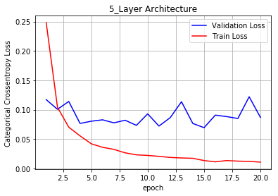

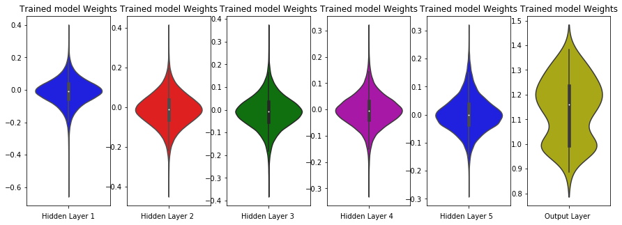

```python
model_relu3 = Sequential()
#layer-1
model_relu3.add(Dense(500, activation='relu', input_shape=(input_dim,), kernel_initializer=RandomNormal(mean=0.0, stddev=0.039, seed=None)))
#adding batch normalization
#model_relu3.add(BatchNormalization())
#addding dropout rate
#model_relu3.add(Dropout(0.2))
#layer-2
model_relu3.add(Dense(400, activation='relu', kernel_initializer=RandomNormal(mean=0.0, stddev=0.039, seed=None)))
#adding batch noramalization
#model_relu3.add(BatchNormalization())
#adding drop out rate
#model_relu3.add(Dropout(0.2))
#layer-3
model_relu3.add(Dense(300, activation='relu', kernel_initializer=RandomNormal(mean=0.0, stddev=0.039, seed=None)))
#adding batch noramalization
#model_relu3.add(BatchNormalization())
#adding drop out rate
#model_relu3.add(Dropout(0.2))
#layer-4
model_relu3.add(Dense(200, activation='relu', kernel_initializer=RandomNormal(mean=0.0, stddev=0.039, seed=None)))
#adding batch noramalization
#model_relu3.add(BatchNormalization())
#adding drop out rate
#model_relu3.add(Dropout(0.2))
#layer-5
model_relu3.add(Dense(100, activation='relu', kernel_initializer=RandomNormal(mean=0.0, stddev=0.039, seed=None)))
#adding batch noramalization
model_relu3.add(BatchNormalization())
#adding drop out rate
model_relu3.add(Dropout(0.5))

model_relu3.add(Dense(output_dim, activation='softmax'))


#print(model_relu3.summary())
#using optimizer adam
model_relu3.compile(optimizer='adam', loss='categorical_crossentropy', metrics=['accuracy'])

history = model_relu3.fit(X_train, Y_train, batch_size=batch_size, epochs=nb_epoch, verbose=1, validation_data=(X_test, Y_test))
#-----------------------------------------------------------------------------------------------------------------------------------------
score_6 = model_relu3.evaluate(X_test, Y_test, verbose=0)
print('Test score:', score_6[0])
print('Test accuracy:', score_6[1])

fig,ax = plt.subplots(1,1)
ax.set_xlabel('epoch')
ax.set_ylabel('Categorical Crossentropy Loss')

# list of epoch numbers
x = list(range(1,nb_epoch+1))

vy = history.history['val_loss']
ty = history.history['loss']
plt_dynamic(x, vy, ty, ax)
plt.title('5_Layer Architecture')
plt.show()

#------------------------------------------------------------------------------------------------------------------------------------------

w_after = model_relu3.get_weights()

h1_w = w_after[0].flatten().reshape(-1,1)
h2_w = w_after[2].flatten().reshape(-1,1)
h3_w = w_after[4].flatten().reshape(-1,1)
h4_w = w_after[6].flatten().reshape(-1,1)
h5_w = w_after[8].flatten().reshape(-1,1)

out_w = w_after[10].flatten().reshape(-1,1)

fig = plt.figure(figsize=(15,5))
plt.title("Weight matrices after model trained")

plt.subplot(1, 6, 1,)

plt.title("Trained model Weights")
ax = sns.violinplot(y=h1_w,color='b')
plt.xlabel('Hidden Layer 1')

plt.subplot(1, 6, 2)
plt.title("Trained model Weights")
ax = sns.violinplot(y=h2_w, color='r')
plt.xlabel('Hidden Layer 2 ')

plt.subplot(1, 6, 3)
plt.title("Trained model Weights")
ax = sns.violinplot(y=h3_w, color='g')
plt.xlabel('Hidden Layer 3 ')


plt.subplot(1, 6, 4)
plt.title("Trained model Weights")
ax = sns.violinplot(y=h4_w,color='m')
plt.xlabel('Hidden Layer 4  ')

plt.subplot(1, 6, 5)
plt.title("Trained model Weights")
ax = sns.violinplot(y=h5_w,color='b')
plt.xlabel('Hidden Layer 5  ')

plt.subplot(1, 6, 6)
plt.title("Trained model Weights")
ax = sns.violinplot(y=out_w,color='y')
plt.xlabel('Output Layer ')
plt.show()
```